# TIMSS 2015 4th Grade

□ بررسی عوامل موثر بر عملکرد دانش آموزان :

در این بخش به بررسی عوامل موثر در عملکرد دانش آموزان پرداخته ایم. هر یک از این عوامل کلی را با دسته بندی به عامل هایی کوچک تر بررسی کرده ایم.  
برای نشان دادن تاثیر این عوامل از آزمون فرض Anova و در بعضی موارد از Chi-Squared استفاده کرده ایم. همینطور برای هر یک ، دو نمودار نیز رسم شده است. این اطلاعات بر حسب جواب مدیر ، معلم ها ، والدین و خود دانش آموزان به پرسشنامه های آزمون بدست آمده است.

### Timss 4th Grade

#### Home Environment Support

در این قسمت، میانگین امتیاز دانش آموزان را برحسب وضعیت محیط خانه با هم مقایسه کرده ایم. برای تعیین وضعیت محیط خانه، عوامل مختلفی مانند

- منابع فیزیکی مانند اتاق مجزا، میز مطالعه، اینترنت و …
- میزان تحصیلات پدر و مادر
- صحبت کردن به زبان امتحان

> منابع فیزیکی:

در این قسمت دانش آموزان را بر حسب دسترسی به میز مطالعه، اتاق مجزا، کامپیوتر و … به دسته های مختلفی تقسیم کرده ایم.

```
##                        Df    Sum Sq   Mean Sq F value Pr(>F)
## as.factor(res.cat)      2 2.240e+08 112022237   14363 <2e-16 ***
## Residuals          269510 2.102e+09      7799
## ---
## Signif. codes:  0 '***' 0.001 '**' 0.01 '*' 0.05 '.' 0.1 ' ' 1
```

```
##
##  Pearson's Chi-squared test with simulated p-value (based on 2000
##  replicates)
##
## data:  matrix(as.numeric(home15.stat4th.summery$freq), nrow = 3)
## X-squared = 24142, df = NA, p-value = 0.0004998
```

[interactive chart not shown]

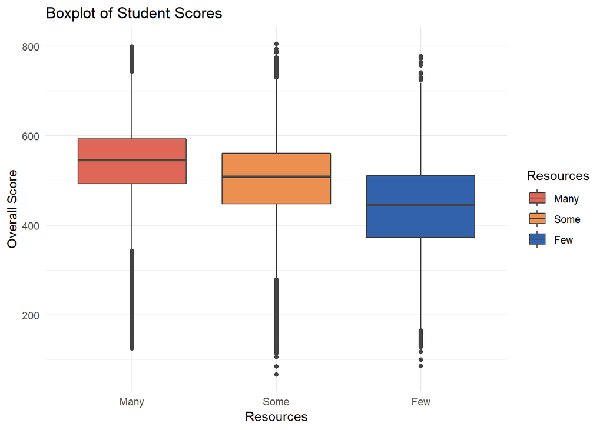

> تحصیلات پدر و مادر:

در این قسمت، بیشترین تحصیلات پدر و مادر را در نظر گرفتیم و دانش آموزان را بر حسب آن دسته بندی کرده ایم و میانگین امتیاز هر دسته را به دست آوردیم.

```
##                     Df    Sum Sq  Mean Sq F value Pr(>F)
## as.factor(hedu)      6 2.242e+08 37362218    4435 <2e-16 ***
## Residuals       286182 2.411e+09     8425
## ---
## Signif. codes:  0 '***' 0.001 '**' 0.01 '*' 0.05 '.' 0.1 ' ' 1
```

```
##
##  Pearson's Chi-squared test with simulated p-value (based on 2000
##  replicates)
##
## data:  matrix(as.numeric(parent15.stat4th.summery$freq), ncol = 7, byrow = T)
## X-squared = 20120, df = NA, p-value = 0.0004998
```

[interactive chart not shown]

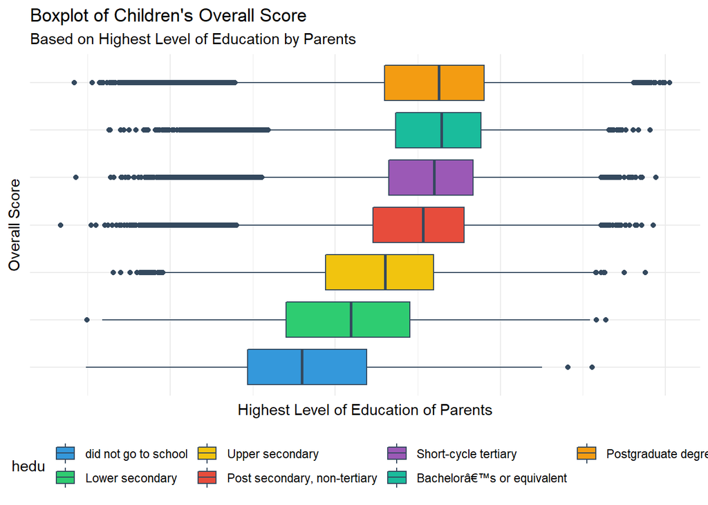

> تسلط به زمان آزمون:

در این قسمت دانش آموزان را بر حسب اینکه چه مقدار در خانه به زبان آزمون صحبت میکنند دسته بندی کرده ایم.

```
##                         Df    Sum Sq  Mean Sq F value Pr(>F)
## as.factor(language)      3 1.052e+08 35080126    4105 <2e-16 ***
## Residuals           278655 2.381e+09     8545
## ---
## Signif. codes:  0 '***' 0.001 '**' 0.01 '*' 0.05 '.' 0.1 ' ' 1
```

```
##
##  Pearson's Chi-squared test
##
## data:  matrix(as.numeric(language15.stat4th.summary$freq), nrow = 4,     byrow = T)
## X-squared = 9789.4, df = 9, p-value < 2.2e-16
```

[interactive chart not shown]

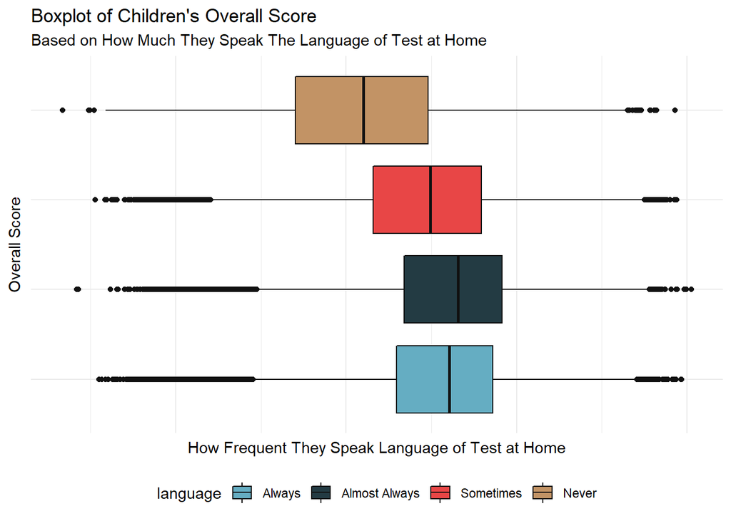

#### School Composition and Resources

> بررسی تاثیر وضعیت اقتصادی دانش آموزان بر عملکرد آن ها در آزمون اساس پاسخ مدیر مدارس. میبینیم که عملکرد مدارسی که بیشتر دانش آموزان آن از خانواده های مرفه هستند بهتر از بقیه مدارس می باشد.

```
##                            Df   Sum Sq Mean Sq F value Pr(>F)
## as.factor(economicState)    2  5527511 2763756   546.7 <2e-16 ***
## Residuals                9114 46073308    5055
## ---
## Signif. codes:  0 '***' 0.001 '**' 0.01 '*' 0.05 '.' 0.1 ' ' 1
```

[interactive chart not shown]

> عملکرد مدارسی که دانش آموزان آن با مهارت کار با اعداد و خواندن وارد دبستان می شوند بهتر از مدارس دیگر است. طلاعات بر اساس پاسخ مدیر می باشد.

```
##                         Df   Sum Sq Mean Sq F value Pr(>F)
## as.factor(skillscore)    2  3661403 1830702   333.4 <2e-16 ***
## Residuals             9467 51987268    5491
## ---
## Signif. codes:  0 '***' 0.001 '**' 0.01 '*' 0.05 '.' 0.1 ' ' 1
```

[interactive chart not shown]

> بررسی تاثیر کمبود امکانات بر روی تدریس. عملکرد مدارسی که کمبودی ندارند به طور واضح بهتر است.

```
##                        Df   Sum Sq Mean Sq F value Pr(>F)
## as.factor(resources)    2  1891580  945790   172.6 <2e-16 ***
## Residuals            9244 50661378    5480
## ---
## Signif. codes:  0 '***' 0.001 '**' 0.01 '*' 0.05 '.' 0.1 ' ' 1
```

[interactive chart not shown]

> نظر معلمان نسبت به وضعیت و امکانات مدرسه. عملکرد در مدارسی که مشکل کمتری دارند بهتر از بقیه می باشد.  
> اطلاعات بر حسب جواب معلمان می باشد.

```
##                         Df    Sum Sq Mean Sq F value Pr(>F)
## as.factor(condition)     2   3366339 1683170   266.5 <2e-16 ***
## Residuals            19456 122860256    6315
## ---
## Signif. codes:  0 '***' 0.001 '**' 0.01 '*' 0.05 '.' 0.1 ' ' 1
```

[interactive chart not shown]

#### School Climate

> تاکید مدرسه بر موفقیت درسی بر روی عملکرد دانش آموزان اثر دارد.

```
##                       Df   Sum Sq Mean Sq F value Pr(>F)
## as.factor(emphasis)    3  3831009 1277003   231.9 <2e-16 ***
## Residuals           9701 53420140    5507
## ---
## Signif. codes:  0 '***' 0.001 '**' 0.01 '*' 0.05 '.' 0.1 ' ' 1
```

[interactive chart not shown]

> بر حسب جواب دانش آموزان به این مورد پرداخته ایم که آیا حس تعلق و راحتی در مدرسه تاثیری بر عملکرد آن ها دارد یا خیر.

```
##                          Df    Sum Sq Mean Sq F value Pr(>F)
## as.factor(belonging)      2 1.306e+06  653243   125.7 <2e-16 ***
## Residuals            269342 1.400e+09    5196
## ---
## Signif. codes:  0 '***' 0.001 '**' 0.01 '*' 0.05 '.' 0.1 ' ' 1
```

[interactive chart not shown]

#### School Discipline and Safety

در این قسمت امنیت و نظم مدرسه را با توجه به سوالات پرسیده شده از دانش آموزان،معلمان و مدیر مدرسه ارزیابی کردیم و میانگین هر دسته را به دست آوردیم.

> از دیدگاه مدیر مدرسه

در این قسمت پاسخ مدیران به سوالاتی در رابطه با مشکلاتی از قبیل:

- دیر آمدن به مدرسه
- غیبت کردن
- تقلب
- دزدی
- و …

را بررسی کردیم و مدارس را مطابقا دسته بندی کردیم.

```
##                         Df   Sum Sq Mean Sq F value Pr(>F)
## as.factor(safety.cat)    3  7161740 2387247   463.3 <2e-16 ***
## Residuals             9644 49695416    5153
## ---
## Signif. codes:  0 '***' 0.001 '**' 0.01 '*' 0.05 '.' 0.1 ' ' 1
```

[interactive chart not shown]

> از دیدگاه معلمان مدرسه

در این قسمت، مانند قسمت قبل پاسخ معلمان را به همان سوالات ارزیابی کردیم و دانش آموزان هر معلم را دسته بندی کردیم.

```
##                          Df    Sum Sq Mean Sq F value Pr(>F)
## as.factor(safety.cat)     3   2681853  893951   141.2 <2e-16 ***
## Residuals             19470 123266503    6331
## ---
## Signif. codes:  0 '***' 0.001 '**' 0.01 '*' 0.05 '.' 0.1 ' ' 1
```

[interactive chart not shown]

> از دیدگاه دانش آموزان

در این قسمت میزان آزار و اذیتی که دانش آموزان از جانب دیگر دانش آموزان میبینند را بررسی کردیم

```
##                             Df    Sum Sq  Mean Sq F value Pr(>F)
## as.factor(bullying.cat)      3 9.002e+07 30007918    3710 <2e-16 ***
## Residuals               262628 2.124e+09     8088
## ---
## Signif. codes:  0 '***' 0.001 '**' 0.01 '*' 0.05 '.' 0.1 ' ' 1
```

```
##
##  Pearson's Chi-squared test
##
## data:  matrix(as.numeric(stud15.stat4th.summary$freq), nrow = 4, ncol = 4,     byrow = T)
## X-squared = 8306.1, df = 9, p-value < 2.2e-16
```

[interactive chart not shown]

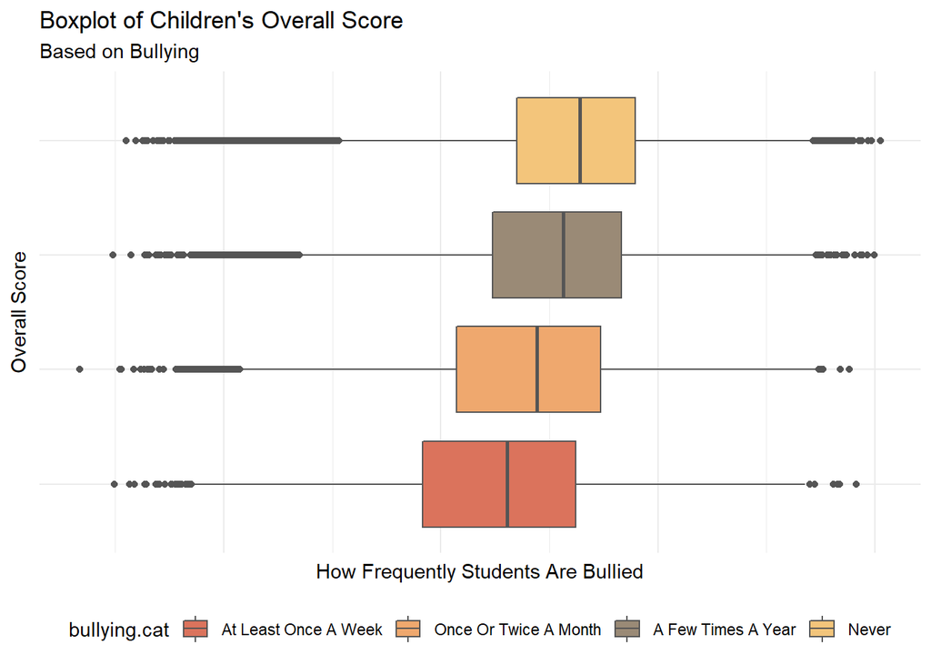

#### Teachers’ and Principals’ Preparation

> تاثیر میزان تجربه مدیر مدرسه بر عملکرد مدرسه در آزمون.

```
##                         Df   Sum Sq Mean Sq F value  Pr(>F)
## as.factor(experience)    3    77801   25934   4.414 0.00416 **
## Residuals             9660 56755264    5875
## ---
## Signif. codes:  0 '***' 0.001 '**' 0.01 '*' 0.05 '.' 0.1 ' ' 1
```

[interactive chart not shown]

> تاثیر میزان تحصیلات مدیر بر روی عملکرد در آزمون.

```
##                        Df   Sum Sq Mean Sq F value Pr(>F)
## as.factor(education)    3  5524399 1841466     345 <2e-16 ***
## Residuals            9803 52329809    5338
## ---
## Signif. codes:  0 '***' 0.001 '**' 0.01 '*' 0.05 '.' 0.1 ' ' 1
```

[interactive chart not shown]

> عملکرد دانش آموزان بر اساس میزان تجربه معلمان.

```
##                          Df    Sum Sq Mean Sq F value Pr(>F)
## as.factor(experience)     3   1943777  647926   103.1 <2e-16 ***
## Residuals             19254 120982392    6283
## ---
## Signif. codes:  0 '***' 0.001 '**' 0.01 '*' 0.05 '.' 0.1 ' ' 1
```

[interactive chart not shown]

> بررسی میزان تحصیلات معلمان بر عملکرد دانش آموزان آن ها.

```
##                         Df    Sum Sq Mean Sq F value Pr(>F)
## as.factor(education)     3   5262442 1754147   292.3 <2e-16 ***
## Residuals            18650 111910719    6001
## ---
## Signif. codes:  0 '***' 0.001 '**' 0.01 '*' 0.05 '.' 0.1 ' ' 1
```

[interactive chart not shown]

#### Classroom Instruction

> محدودیت معلمان در هنگام تدریس بر حسب نیاز دانش آموزان نیز بر عملکرد آن ها تاثیر دارد.

```
##                     Df    Sum Sq Mean Sq F value Pr(>F)
## as.factor(limit)     2   7652753 3826377   633.1 <2e-16 ***
## Residuals        18965 114625002    6044
## ---
## Signif. codes:  0 '***' 0.001 '**' 0.01 '*' 0.05 '.' 0.1 ' ' 1
```

[interactive chart not shown]

> عملکرد دانش آموزان بر حسب تعداد غیبت آن ها.

```
##                       Df    Sum Sq  Mean Sq F value Pr(>F)
## as.factor(absent)      3 7.517e+07 25057911    4839 <2e-16 ***
## Residuals         273917 1.418e+09     5178
## ---
## Signif. codes:  0 '***' 0.001 '**' 0.01 '*' 0.05 '.' 0.1 ' ' 1
```

[interactive chart not shown]

> میزان زمان تدریس بر عملکرد دانش آموزان تاثیر دارد. نکته قابل توجه این است که این دو با یکدیگر رابطه عکس دارند.

```
##                    Df   Sum Sq Mean Sq F value Pr(>F)
## as.factor(hours)    3  1007191  335730   61.81 <2e-16 ***
## Residuals        8787 47725535    5431
## ---
## Signif. codes:  0 '***' 0.001 '**' 0.01 '*' 0.05 '.' 0.1 ' ' 1
```

[interactive chart not shown]

#### Student Engagement and Attitudes

> مشارکت در کلاس

در این قسمت پاسخ دانش آموزان به سوالاتی در رابطه با کلاس ریاضی شان مانند :

- علاقه به مباحث کلاس
- فن بیان معلم
- تنوع در نحوه ی تدریس
- و …

را بررسی کردیم و بر حسب میزان مشارکت، آن ها را دسته بندی کردیم

```
##                            Df    Sum Sq Mean Sq F value Pr(>F)
## as.factor(lessons.cat)      3 4.469e+06 1489668   174.1 <2e-16 ***
## Residuals              265362 2.270e+09    8555
## ---
## Signif. codes:  0 '***' 0.001 '**' 0.01 '*' 0.05 '.' 0.1 ' ' 1
```

```
##
##  Pearson's Chi-squared test
##
## data:  matrix(as.numeric(mstudles15.stat4th.summary$freq), nrow = 4,     ncol = 4, byrow = T)
## X-squared = 731.24, df = 9, p-value < 2.2e-16
```

[interactive chart not shown]

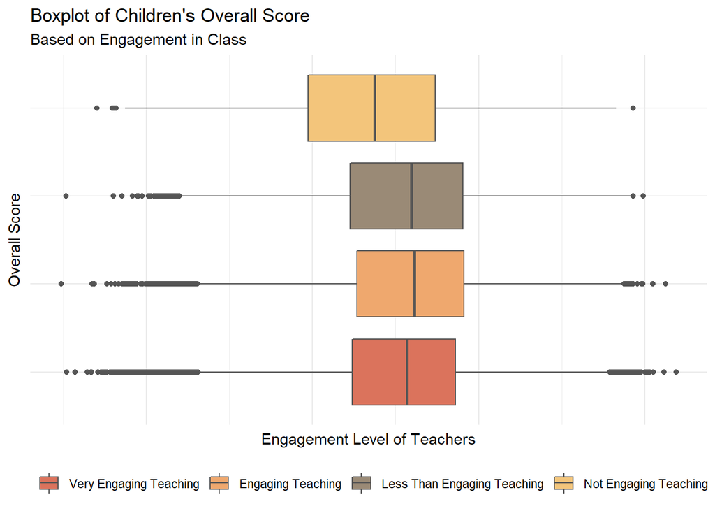

> علاقه به ریاضی

در این قسمت پاسخ دانش آموزان به سوالاتی در رابطه با علاقه به ریاضیات و یادگیری را بررسی کردیم.

```
##                             Df    Sum Sq  Mean Sq F value Pr(>F)
## as.factor(learning.cat)      3 3.517e+07 11723551    1393 <2e-16 ***
## Residuals               261805 2.203e+09     8414
## ---
## Signif. codes:  0 '***' 0.001 '**' 0.01 '*' 0.05 '.' 0.1 ' ' 1
```

```
##
##  Pearson's Chi-squared test
##
## data:  matrix(as.numeric(mstudlearn15.stat4th.summary$freq), nrow = 4,     ncol = 4, byrow = T)
## X-squared = 5407.6, df = 9, p-value < 2.2e-16
```

[interactive chart not shown]

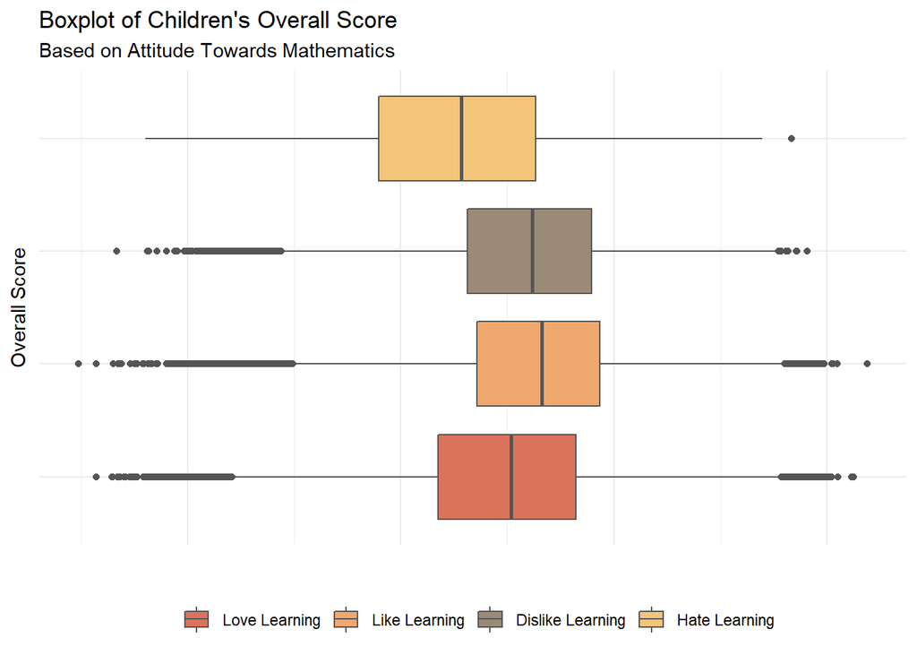

> اعتماد به نفس

در این قسمت دانش آموزان را بر حسب اعتماد به نفسشان در رابطه با ریاضی دسته بندی کردیم.

```
##                               Df    Sum Sq   Mean Sq F value Pr(>F)
## as.factor(confidence.cat)      2 2.241e+08 112071046   14741 <2e-16 ***
## Residuals                 256602 1.951e+09      7602
## ---
## Signif. codes:  0 '***' 0.001 '**' 0.01 '*' 0.05 '.' 0.1 ' ' 1
```

```
##
##  Pearson's Chi-squared test
##
## data:  matrix(as.numeric(mstudconf15.stat4th.summary$freq), ncol = 3,     byrow = T)
## X-squared = 21363, df = 6, p-value < 2.2e-16
```

[interactive chart not shown]

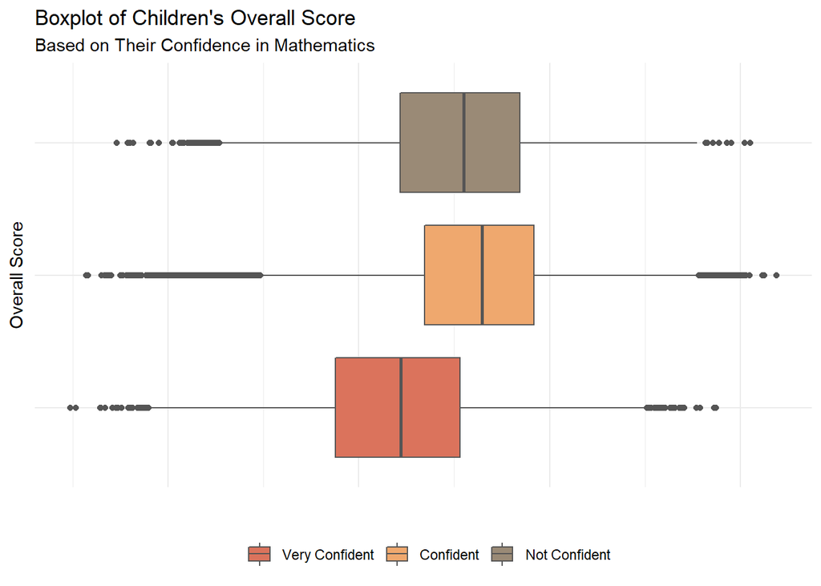